# Panel Analysis Example

This script serves as an example/playground for panel data operations. Initially, we will explore how pandas structures panel data. The brief discussion in [McKinney's book](http://www.amazon.com/books/dp/1449319793) reads in panel data from an external source (Yahoo financial data), using the following syntax: >panel_data=pd.Panel(dict((x,web.get_data_fred(x,start_date,end_date)) for x in x_list))

In this formulation, we have pulled data from the [St. Louis Fed](http://research.stlouisfed.org/fred2/) instead of Yahoo financial. The x represents an indicator, and x_list represents ... a list of indicators. We will unpack this call so that we can abstract to a more general formulation for panel data.

In the first cell, we simply get a sense of how much work the FRED pull is doing in this scheme.

```
***TYPE AND SHAPE OF OUTPUT***
<class 'pandas.core.frame.DataFrame'> (22, 1)
```

| DATE | DCPCPI |
| --- | --- |
| 1990-01-01 | 26015 |
| 1991-01-01 | 27333 |
| 1992-01-01 | 28694 |
| 1993-01-01 | 29883 |
| 1994-01-01 | 30804 |

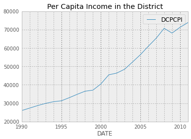

```python
import pandas.io.data as web
import numpy as np
import pandas as pd
from pandas import Series,DataFrame
pd.options.display.mpl_style='default'
from IPython.display import HTML

#Print one example feed from the FRED API
ex_feed=web.get_data_fred('DCPCPI','1/1/1990','12/31/2012')

#Examine data structure
print '***TYPE AND SHAPE OF OUTPUT***'
print type(ex_feed),ex_feed.shape
ex_feed.plot(kind='line',title='Per Capita Income in the District')
ex_feed.head()
```

As can be seen, one single-indicator call to FRED returns a time series. The wrapper automatically houses this data in a DataFrame and indexes the data by timestamp. If we were to wrap this call in a loop over a sequence of indicators, we would simply get several conceptually identical data structures, one for each indicator. We could place these in a list for easy access...

```
<class 'pandas.core.frame.DataFrame'>
            DCPCPI
DATE
1990-01-01   26015
1991-01-01   27333
1992-01-01   28694
1993-01-01   29883
1994-01-01   30804
<class 'pandas.core.frame.DataFrame'>
            MDPCPI
DATE
1990-01-01   22681
1991-01-01   23282
1992-01-01   24112
1993-01-01   24805
1994-01-01   25780
<class 'pandas.core.frame.DataFrame'>
            VAPCPI
DATE
1990-01-01   20312
1991-01-01   20953
1992-01-01   21842
1993-01-01   22596
1994-01-01   23534
```

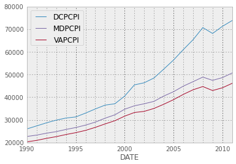

```python
#Identify per capita income in DC, MD, and VA
dseries=['DCPCPI','MDPCPI','VAPCPI']

#Capture feeds for each indicator in list
series_list=[]
for ind in dseries:
    series_list.append(web.get_data_fred(ind,'1/1/1990','12/31/2012'))

#Print data
for series in series_list:
    print type(series),'\n',series.head()

#Plot data
pd.concat(series_list,axis=1).plot(kind='line')
```

This is where things get interesting. pd.Panel actually takes a [dictionary](http://interactivepython.org/courselib/static/thinkcspy/Dictionaries/dictionaries.html) argument, with each key corresponding to a different group in the panel. The dictionary constructor used in the McKinney example is actually a little unusual. It relies on the fact that dictionaries can be built from [tuples](http://interactivepython.org/courselib/static/thinkcspy/Lists/lists.html#tuples-and-mutability).

A brief example will show what I mean. We will construct the following dictionary: >ex_dict={'a':[1,2,3],'b':[1,2,3],'c':[1,2,3]}

Disregard the fact that the values for each key are the same. With the FRED data, they will actually be different by virtue of calling different indicators. (The indicator will be used to both name the key and function as the first argument in the web.get_fred_data pull.)

We will build the dictionary in two ways: verbose and compact.

```python
"""Verbose Build"""
print '***VERBOSE CONSTRUCTION***'
#Create a list of dictionary keys
v_keys=['a','b','c']

#Creat list of value arrays
v_values=[[1,2,3]]*3
print 'KEYS:',v_keys,'\nVALUES:',v_values

#Create tuples
v_tuple0=(v_keys[0],v_values[0])
v_tuple1=(v_keys[1],v_values[1])
v_tuple2=(v_keys[2],v_values[2])

#Put tuples in list
v_tuple_list=[v_tuple0,v_tuple1,v_tuple2]
print 'TUPLE LIST:',v_tuple_list

#Generate dictionary
v_dict=dict(v_tuple_list)
print 'DICTIONARY:',v_dict

"""Compact Build"""
print '\n***COMPACT CONSTRUCTION***'
#Create a list of dictionary keys
c_keys=['a','b','c']

#Creat list of value arrays
c_values=[[1,2,3]]*3
print 'KEYS:',c_keys,'\nVALUES:',c_values

#Create dictionary
c_dict=dict((c_keys[i],c_values[i]) for i in range(len(c_keys)))
print 'DICTIONARY:',c_dict
```

```
***VERBOSE CONSTRUCTION***
KEYS: ['a', 'b', 'c']
VALUES: [[1, 2, 3], [1, 2, 3], [1, 2, 3]]
TUPLE LIST: [('a', [1, 2, 3]), ('b', [1, 2, 3]), ('c', [1, 2, 3])]
DICTIONARY: {'a': [1, 2, 3], 'c': [1, 2, 3], 'b': [1, 2, 3]}

***COMPACT CONSTRUCTION***
KEYS: ['a', 'b', 'c']
VALUES: [[1, 2, 3], [1, 2, 3], [1, 2, 3]]
DICTIONARY: {'a': [1, 2, 3], 'c': [1, 2, 3], 'b': [1, 2, 3]}
```

This method just embeds looping capability into a single line to provide more functionality per keystroke. Anyway, getting back to the FRED data, here is the constructed dictionary...

```python
#Construct dictionary from feeds
feed=dict((series,web.get_data_fred(series,'1/1/1990','12/31/2012')) for series in dseries)
print feed
```

```
{'DCPCPI':             DCPCPI
DATE
1990-01-01   26015
1991-01-01   27333
1992-01-01   28694
1993-01-01   29883
1994-01-01   30804
1995-01-01   31291
1996-01-01   32981
1997-01-01   34807
1998-01-01   36503
1999-01-01   37093
2000-01-01   40462
2001-01-01   45421
2002-01-01   46347
2003-01-01   48451
2004-01-01   52362
2005-01-01   56362
2006-01-01   60957
2007-01-01   65329
2008-01-01   70686
2009-01-01   68093
2010-01-01   71220
2011-01-01   73783, 'VAPCPI':             VAPCPI
DATE
1990-01-01   20312
1991-01-01   20953
1992-01-01   21842
1993-01-01   22596
1994-01-01   23534
1995-01-01   24360
1996-01-01   25354
1997-01-01   26695
1998-01-01   28199
1999-01-01   29617
2000-01-01   31634
2001-01-01   33246
2002-01-01   33737
2003-01-01   35033
2004-01-01   36869
```

[output cut: 15 more lines]

```
1997-01-01   29000
1998-01-01   30742
1999-01-01   32216
2000-01-01   34678
2001-01-01   36203
2002-01-01   37092
2003-01-01   38153
2004-01-01   40499
2005-01-01   42405
2006-01-01   44858
2007-01-01   46839
2008-01-01   48864
2009-01-01   47419
2010-01-01   48621
2011-01-01   50656}
```

Now we can place the data in a Panel data structure. Notice that examining a group only displays information from that group. This is because even though all of the columns show the same concept, they are not called the same thing. Thus, they are treated as different variables. We will fix this by renaming during the construction of the Panel set below.

```python
#Create Panel data structure
pdata=pd.Panel(feed)
print pdata

#Examine Maryland data
pdata['MDPCPI']
```

```
<class 'pandas.core.panel.Panel'>
Dimensions: 3 (items) x 22 (major_axis) x 3 (minor_axis)
Items axis: DCPCPI to VAPCPI
Major_axis axis: 1990-01-01 00:00:00 to 2011-01-01 00:00:00
Minor_axis axis: DCPCPI to VAPCPI
```

| DATE | DCPCPI | MDPCPI | VAPCPI |
| --- | --- | --- | --- |
| 1990-01-01 | NaN | 22681 | NaN |
| 1991-01-01 | NaN | 23282 | NaN |
| 1992-01-01 | NaN | 24112 | NaN |
| 1993-01-01 | NaN | 24805 | NaN |
| 1994-01-01 | NaN | 25780 | NaN |
| 1995-01-01 | NaN | 26618 | NaN |
| 1996-01-01 | NaN | 27689 | NaN |
| 1997-01-01 | NaN | 29000 | NaN |
| 1998-01-01 | NaN | 30742 | NaN |
| 1999-01-01 | NaN | 32216 | NaN |
| 2000-01-01 | NaN | 34678 | NaN |
| 2001-01-01 | NaN | 36203 | NaN |
| 2002-01-01 | NaN | 37092 | NaN |
| 2003-01-01 | NaN | 38153 | NaN |
| 2004-01-01 | NaN | 40499 | NaN |
| 2005-01-01 | NaN | 42405 | NaN |
| 2006-01-01 | NaN | 44858 | NaN |
| 2007-01-01 | NaN | 46839 | NaN |
| 2008-01-01 | NaN | 48864 | NaN |
| 2009-01-01 | NaN | 47419 | NaN |
| 2010-01-01 | NaN | 48621 | NaN |
| 2011-01-01 | NaN | 50656 | NaN |

Now we should start thinking about what we might actually do from an analytical standpoint. Let's say we are designating per capita income as our dependent variable. What about regressors? This script is more about working with data in pandas than model specification, so we are going to just grab a few variables that already sit in FRED. Items that could affect per capita income:

> 1. Business cycle via unemployment rate proxy (*UR)
> 2. Population density (*POP - this is only population, but we can identify the land area)
> 3. Government employment (*GOVTN)

Perhaps we want to make the case that health insurance coverage impacts earnings by preventing disruptive losses from derailing earning trajectories of workers. Our weird variable of interest, then, is health insurance coverage percentage (*HICCOVPCT). Note that the data for this variable go back only to 1999.

Given that the input for Panel is just a dictionary that holds DataFrames, we can construct this dictionary any way we like. We will use a strategy that tries to minimize the editing scope if we decide we want to change variables or states.

```python
#Construct list of indicator suffixes (will be joined programmatically with states)
ind_suffix_list=['PCPI','UR','POP','GOVTN','HICCOVPCT']

#Construct state list
state_list=['DC','MD','VA']

#Construct land area list
land_area=[68.3,12407.0,42775.0]

#Create function to generate dictionary
def fred_dict(groups,indicators,start_date,end_date,comvar):
    """Function grabs FRED data and constructs a dictionary:

            'jurisdiction':[DataFrame holding associated variables]

        ***Note that this function aggregates to yearly values via mean().***
    """
    #Create container for group-specific DFs (will be bound to group names in output dict)
    df_list=[]
    i=0
    for group in groups:
        #Create container for within group DFs (for each indicator)
        subdf_list=[]
        #Create container for full indicator names (for use in renaming)
        indic_list=[]
        for indic in indicators:
            #Construct indicator name and throw it in indic_list
            ind=group+indic
            indic_list.append(ind)
            #Call data and throw it into the within group DF list
            subdf_list.append(web.get_data_fred(ind,start_date,end_date))
        #Concatenate to one DF per group
        df=pd.concat(subdf_list,axis=1)
        #Annualize data by averaging over each year
        df2=df.groupby(df.index.year).mean()
        #Create renaming dictionary
        rename_dict=dict(zip(indic_list,comvar))
        #Rename columns
        df3=df2.rename(columns=rename_dict)
        #Add in state land area for use in constructing population density
        df3['area']=land_area[i]
        i+=1
        #Calculate population density
        df3['POP_DENS']=df3['POP']/df3['area']
        #Drop population and area columns
        df3.pop('area')
        df3.pop('POP')
        #Throw group DFs into a values list for binding with keys
        df_list.append(df3)
    #Construct output dictionary
    df_dict=(dict(zip(groups,df_list)))
    return df_dict

#Generate Panel input
panel_input=fred_dict(state_list,ind_suffix_list,'1/1/1999','12/31/2011',ind_suffix_list)
print panel_input
```

```
{'MD':        PCPI        UR       GOVTN  HICCOVPCT  POP_DENS
1999  32216  3.633333  444.241667       90.0  0.416832
2000  34678  3.550000  449.925000       91.0  0.428068
2001  36203  4.058333  456.708333       89.0  0.433198
2002  37092  4.475000  464.650000       88.3  0.438494
2003  38153  4.475000  462.375000       87.8  0.442997
2004  40499  4.291667  462.483333       88.1  0.447081
2005  42405  4.116667  465.991667       86.9  0.450744
2006  44858  3.825000  471.158333       86.8  0.453564
2007  46839  3.433333  478.425000       87.3  0.455663
2008  48864  4.300000  487.741667       88.6  0.458206
2009  47419  7.366667  493.991667       86.7  0.461867
2010  48621  7.816667  501.583333       87.2  0.466511
2011  50656  7.275000  504.658333       86.2  0.470668, 'DC':        PCPI         UR       GOVTN  HICCOVPCT  POP_DENS
1999  37093   6.491667  222.475000       86.0  7.598829
```

[output cut: 25 more lines]

Now we can create our Panel structure, and see if we can actually analyze this piece. The Panel class is only a data structure. Methods for analysis sit in a different location: ols. ols can take Panel data structures as inputs.

```python
health=pd.Panel(panel_input)
print health
```

```
<class 'pandas.core.panel.Panel'>
Dimensions: 3 (items) x 13 (major_axis) x 5 (minor_axis)
Items axis: DC to VA
Major_axis axis: 1999 to 2011
Minor_axis axis: PCPI to POP_DENS
```

To ease our way into things, we can perform basic Ordinary Least Squares on one group at a time. To get the appropriate slice, we index along each axis (items, major, and minor). In our data set, these correspond to (state,year,and variables) respectively.

```python
#Slice down to states
dc=health.ix['DC']
md=health.ix['MD']
va=health.ix['VA']

#Create column slice lists
y_col='PCPI'
x_col=['GOVTN','HICCOVPCT','POP_DENS','UR']

#Run OLS
dc_res=pd.ols(y=dc[y_col], x=dc[x_col])
md_res=pd.ols(y=md[y_col], x=md[x_col])
va_res=pd.ols(y=va[y_col], x=va[x_col])
print dc_res,md_res,va_res
```

```
-------------------------Summary of Regression Analysis-------------------------

Formula: Y ~ <GOVTN> + <HICCOVPCT> + <POP_DENS> + <UR> + <intercept>

Number of Observations:         13
Number of Degrees of Freedom:   5

R-squared:         0.9152
Adj R-squared:     0.8728

Rmse:           4476.2752

F-stat (4, 8):    21.5827, p-value:     0.0002

Degrees of Freedom: model 4, resid 8

-----------------------Summary of Estimated Coefficients------------------------
      Variable       Coef    Std Err     t-stat    p-value    CI 2.5%   CI 97.5%
--------------------------------------------------------------------------------
         GOVTN  1765.0693   517.1908       3.41     0.0092   751.3753  2778.7633
     HICCOVPCT  2636.0382  1139.3389       2.31     0.0494   402.9339  4869.1425
      POP_DENS -6336.0061  7771.2264      -0.82     0.4385 -21567.6098  8895.5976
            UR -1901.2201  1922.6173      -0.99     0.3517 -5669.5501  1867.1098
     intercept -520761.6885 76238.5128      -6.83     0.0001 -670189.1736 -371334.2034
---------------------------------End of Summary---------------------------------

-------------------------Summary of Regression Analysis-------------------------

Formula: Y ~ <GOVTN> + <HICCOVPCT> + <POP_DENS> + <UR> + <intercept>

Number of Observations:         13
Number of Degrees of Freedom:   5

R-squared:         0.9832
Adj R-squared:     0.9748

Rmse:            972.5220

F-stat (4, 8):   117.1042, p-value:     0.0000

```

[output cut: 22 more lines]

```
Rmse:            502.7606

F-stat (4, 8):   362.6896, p-value:     0.0000

Degrees of Freedom: model 4, resid 8

-----------------------Summary of Estimated Coefficients------------------------
      Variable       Coef    Std Err     t-stat    p-value    CI 2.5%   CI 97.5%
--------------------------------------------------------------------------------
         GOVTN   112.6003    29.9852       3.76     0.0056    53.8292   171.3713
     HICCOVPCT   -99.6555   157.9189      -0.63     0.5456  -409.1767   209.8656
      POP_DENS 277647.8430 121874.6238       2.28     0.0522 38773.5802 516522.1057
            UR  -728.4606   138.3669      -5.26     0.0008  -999.6597  -457.2616
     intercept -73305.7629 17912.0828      -4.09     0.0035 -108413.4452 -38198.0806
---------------------------------End of Summary---------------------------------
```

Now, these summaries look nice, but what if we want to actually do something with some of the output? The output objects have methods of their own that extract elements of the analysis. One may wish, for example, to compare the impact of each element across states.

```python
#Create DF for comparison
##Throw results in a list
res_list=[dc_res,md_res,va_res]
##Create list of state names in the same order as results
res_state=['DC','MD','VA']
##Creat container for result parameters (so we can merge)
res_out=[]
for i in range(len(res_list)):
    #Grab parameters of interest
    out=[res_list[i].beta,res_list[i].p_value]
    #Create DF from parameters, renaming the columns appropriately
    res_df=pd.concat(out,axis=1).rename(columns={0:'beta',1:'pval'})
    #Remove intercept and rename index
    res_df2=res_df[res_df.index!='intercept']
    #Add state identifier
    res_df2['STATE']=res_state[i]
    #Output transposed parameter DFs to list
    res_out.append(res_df2)
#Concatenate to one output parameter DF
out_param=pd.concat(res_out)

#Add state to index
out_param.set_index('STATE',append=True,inplace=True)

out_param
```

|  | STATE | beta | pval |
| --- | --- | --- | --- |
| GOVTN | DC | 1765.069302 | 0.009185 |
| HICCOVPCT | DC | 2636.038167 | 0.049406 |
| POP_DENS | DC | -6336.006097 | 0.438489 |
| UR | DC | -1901.220142 | 0.351688 |
| GOVTN | MD | 243.602496 | 0.010536 |
| HICCOVPCT | MD | 84.545048 | 0.849990 |
| POP_DENS | MD | 195605.368268 | 0.062457 |
| UR | MD | -1360.955806 | 0.006668 |
| GOVTN | VA | 112.600273 | 0.005583 |
| HICCOVPCT | VA | -99.655547 | 0.545607 |
| POP_DENS | VA | 277647.842956 | 0.052222 |
| UR | VA | -728.460630 | 0.000760 |

Looks like we have a usable DF, and we can make some comparisons. These comparisons would be easier to see graphically, so let's plot the data. Ideally we could have color mapped to the p_value, so we could have a clear idea of the relative significance of each estimate. This is fairly trivial with ggplot2 (in R), but using *rmagic* is not the subject of this script. Consequently, we will make do with the sometimes clunky matplotlib.

The workaround is to create discrete color mapping in a new variable. Based upon popular notions of statistical significance, we will assign three colors based upon p-value breakpoints of .05 and .1. The darker the color (light: green, medium: blue, dark: purple), the higher the degree of "statistical significance" based upon our p-value metric.

Note that to create this plot, we could not rely on the pandas DataFrame.plot() method. These methods are merely pandas wrappers for [matplotlib](http://matplotlib.org/), so we only gather a subset of the functionality. Usually it's ample, but sometimes we need more...

|  | STATE | beta | pval | color |
| --- | --- | --- | --- | --- |
| GOVTN | DC | 1765.069302 | 0.009185 | #4F23B6 |
| HICCOVPCT | DC | 2636.038167 | 0.049406 | #4F23B6 |
| POP_DENS | DC | -6336.006097 | 0.438489 | #23B799 |
| UR | DC | -1901.220142 | 0.351688 | #23B799 |
| GOVTN | MD | 243.602496 | 0.010536 | #4F23B6 |
| HICCOVPCT | MD | 84.545048 | 0.849990 | #23B799 |
| POP_DENS | MD | 195605.368268 | 0.062457 | #238AB7 |
| UR | MD | -1360.955806 | 0.006668 | #4F23B6 |
| GOVTN | VA | 112.600273 | 0.005583 | #4F23B6 |
| HICCOVPCT | VA | -99.655547 | 0.545607 | #23B799 |
| POP_DENS | VA | 277647.842956 | 0.052222 | #238AB7 |
| UR | VA | -728.460630 | 0.000760 | #4F23B6 |

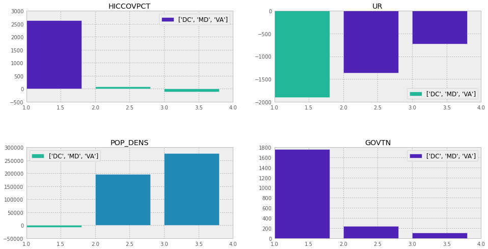

```python
#Create color variable
out_param['color']=''

#Map colors to p-values
out_param.ix[out_param['pval']<=.05,'color']='#4F23B6'
out_param.ix[(out_param['pval']>.05) & (out_param['pval']<=.1),'color']='#238AB7'
out_param.ix[out_param['pval']>.1,'color']='#23B799'

#Set figure size
pylab.rcParams['figure.figsize'] = 16, 8

#Create subplots
fig,axes=plt.subplots(2,2)

#Plot coefficients
axes_list=[axes[0,0],axes[0,1],axes[1,0],axes[1,1]]
i=0
for indic in set(out_param.index.get_level_values(level=0)):
    beta=list(out_param.ix[indic]['beta'].values)
    ind=list(out_param.ix[indic]['beta'].index)
    colors=list(out_param.ix[indic]['color'].values)
    axes_list[i].bar([1,2,3],beta,color=colors,label=['DC','MD','VA'])
    axes_list[i].legend(loc='best')
    axes_list[i].set_title(indic)
    i+=1

out_param
```

The summary output from OLS and other model output is its own type of object (class pandas.stats.ols.OLS), with its own methods. If you ever need to recall the type of an object, or the associated methods, you can do so with the commands below. This is useful if you want to, for instance, extract something other than beta/p-values.

```python
#What type of object is the summary output?
print type(dc_res)

#What else can I pull out of that guy?
dir(type(dc_res))
```

```
<class 'pandas.stats.ols.OLS'>
```

```
['RESULT_FIELDS',
 '__class__',
 '__delattr__',
 '__dict__',
 '__doc__',
 '__format__',
 '__getattribute__',
 '__hash__',
 '__init__',
 '__module__',
 '__new__',
 '__reduce__',
 '__reduce_ex__',
 '__repr__',
 '__setattr__',
 '__sizeof__',
 '__str__',
 '__subclasshook__',
 '__weakref__',
 '_beta_raw',
 '_coef_table',
 '_df_model_raw',
 '_df_raw',
 '_df_resid_raw',
 '_f_stat_raw',
 '_nobs',
 '_p_value_raw',
 '_panel_model',
 '_prepare_data',
 '_r2_adj_raw',
 '_r2_raw',
 '_resid_raw',
 '_results',
 '_rmse_raw',
 '_std_err_raw',
 '_t_stat_raw',
 '_time_obs_count',
 '_total_times',
 '_use_centered_tss',
 '_var_beta_raw',
```

[output cut: 10 more lines]

```
 'p_value',
 'predict',
 'r2',
 'r2_adj',
 'resid',
 'rmse',
 'std_err',
 'summary',
 'summary_as_matrix',
 't_stat',
 'var_beta',
 'x',
 'y',
 'y_fitted',
 'y_predict']
```

The results above (superficially) suggest that state-specific factors are quite important in determining the impact of our covariates on per capita income. We, thus, have cause to explore the panel nature of these data.

Note that we will be using our Panel structure for this section instead of indexing down to a single DataFrame. This increases the dimensionality of our inputs. When we ran OLS above, our dependent (y_ols) was a single Series, basically a 1-D array. Our covariates (X_ols) were housed in a DataFrame, a 2-D array. Now that we are performing panel analysis, our dependent (y_panel) will be a DataFrame of the same length as our previous dependent (y_ols). However, it now has three columns, one for each group.

```python
#y=dc['DCPCPI'], x=dc[['DCGOVTN','DCHICCOVPCT','DCPOP','DCUR']]
#dc=health.ix['DC',:,:5]
#md=health.ix['MD',:,5:10]
#va=health.ix['VA',:,10:]
print '***y_ols for DC***\n',health.ix['DC',:,'PCPI']
print '***y_panel***\n',health.ix[:,:,'PCPI']
```

```
***y_ols for DC***
1999    37093
2000    40462
2001    45421
2002    46347
2003    48451
2004    52362
2005    56362
2006    60957
2007    65329
2008    70686
2009    68093
2010    71220
2011    73783
Name: PCPI, dtype: float64
***y_panel***
         DC     MD     VA
1999  37093  32216  29617
2000  40462  34678  31634
2001  45421  36203  33246
2002  46347  37092  33737
2003  48451  38153  35033
2004  52362  40499  36869
2005  56362  42405  38898
2006  60957  44858  41218
2007  65329  46839  43261
2008  70686  48864  44691
2009  68093  47419  42929
2010  71220  48621  44134
2011  73783  50656  46107
```

Our new covariates (X_panel) are now housed in a 3-D array. You can think of it as having three DataFrames (one for each group) stacked on top of one another.

```python
print '***X_ols for DC***\n',type(health.ix['DC',:,['GOVTN','HICCOVPCT','POP_DENS','UR']]),'\n', \
                                  health.ix['DC',:,['GOVTN','HICCOVPCT','POP_DENS','UR']]
print '***X_panel (to_frame)***\n',type(health.ix[:,:,['GOVTN','HICCOVPCT','POP_DENS','UR']].to_frame()),'\n', \
                                        health.ix[:,:,['GOVTN','HICCOVPCT','POP_DENS','UR']].to_frame()
print '***X_panel***\n',health.ix[:,:,['GOVTN','HICCOVPCT','POP_DENS','UR']]
```

```
***X_ols for DC***
<class 'pandas.core.frame.DataFrame'>
           GOVTN  HICCOVPCT  POP_DENS         UR
1999  222.475000       86.0  7.598829   6.491667
2000  223.958333       87.2  8.375490   5.691667
2001  226.133333       87.7  8.411479   6.216667
2002  231.700000       87.0  8.391772   6.750000
2003  230.641667       87.3  8.323602   7.008333
2004  231.266667       88.0  8.312650   7.325000
2005  233.716667       87.6  8.303602   6.566667
2006  233.041667       89.1  8.355505   5.708333
2007  231.000000       90.7  8.410015   5.475000
2008  234.841667       90.6  8.495403   6.600000
2009  240.258333       87.6  8.670981   9.633333
2010  246.925000       87.2  8.857818  10.108333
2011  247.091667       91.6  9.063250  10.025000
***X_panel (to_frame)***
<class 'pandas.core.frame.DataFrame'>
                         DC          MD          VA
major minor
1999  GOVTN      222.475000  444.241667  611.250000
      HICCOVPCT   86.000000   90.000000   88.700000
      POP_DENS     7.598829    0.416832    0.160676
      UR           6.491667    3.633333    2.658333
2000  GOVTN      223.958333  449.925000  624.700000
      HICCOVPCT   87.200000   91.000000   90.400000
      POP_DENS     8.375490    0.428068    0.166121
      UR           5.691667    3.550000    2.300000
2001  GOVTN      226.133333  456.708333  629.208333
      HICCOVPCT   87.700000   89.000000   90.200000
      POP_DENS     8.411479    0.433198    0.168284
      UR           6.216667    4.058333    3.241667
2002  GOVTN      231.700000  464.650000  634.900000
      HICCOVPCT   87.000000   88.300000   88.200000
      POP_DENS     8.391772    0.438494    0.170354
      UR           6.750000    4.475000    4.183333
2003  GOVTN      230.641667  462.375000  637.508333
      HICCOVPCT   87.300000   87.800000   88.500000
      POP_DENS     8.323602    0.442997    0.172226
      UR           7.008333    4.475000    4.108333
```

[output cut: 23 more lines]

```
      UR           9.633333    7.366667    6.941667
2010  GOVTN      246.925000  501.583333  704.741667
      HICCOVPCT   87.200000   87.200000   86.000000
      POP_DENS     8.857818    0.466511    0.187612
      UR          10.108333    7.816667    7.091667
2011  GOVTN      247.091667  504.658333  710.333333
      HICCOVPCT   91.600000   86.200000   86.600000
      POP_DENS     9.063250    0.470668    0.189465
      UR          10.025000    7.275000    6.450000
***X_panel***
<class 'pandas.core.panel.Panel'>
Dimensions: 3 (items) x 13 (major_axis) x 4 (minor_axis)
Items axis: DC to VA
Major_axis axis: 1999 to 2011
Minor_axis axis: GOVTN to UR
```

*The pandas ols class will recognize the shift in inputs, and alter the way it treats the data.* Furthermore, additional options (pool, entity_effects, time_effects, etc.) for panel analysis will become available.

First, let's try to abstract away from specific states, and explore a pooled model. **Note that the minor axis in the X Panel object (x_panel) must correspond with the column names in the y DataFrame (y_panel). If this is not the case, trying to run the panel analysis will throw a cryptic error.** The one I saw was a math domain error (essentially claiming the instance of a figure value that could not be achieved, like a log operation returning a negative number), and the stack trace pointed to a specific line number rather than associated code (which I moved around when attempting to print values). Save yourself the hassle and just make sure your axes are where they are supposed to be (this is the reason for .swapaxes() call below).

```python
y_panel=health.ix[:,:,'PCPI']
x_panel=health.ix[:,:,['GOVTN','HICCOVPCT','POP_DENS','UR']].swapaxes('items','minor')
hpool=pd.ols(y=y_panel, x=x_panel)
print hpool
```

```
-------------------------Summary of Regression Analysis-------------------------

Formula: Y ~ <GOVTN> + <HICCOVPCT> + <POP_DENS> + <UR> + <intercept>

Number of Observations:         39
Number of Degrees of Freedom:   5

R-squared:         0.6789
Adj R-squared:     0.6411

Rmse:           6934.8047

F-stat (4, 34):    17.9682, p-value:     0.0000

Degrees of Freedom: model 4, resid 34

-----------------------Summary of Estimated Coefficients------------------------
      Variable       Coef    Std Err     t-stat    p-value    CI 2.5%   CI 97.5%
--------------------------------------------------------------------------------
         GOVTN     8.3230    14.5410       0.57     0.5708   -20.1774    36.8234
     HICCOVPCT  1514.7895   817.5523       1.85     0.0726   -87.6129  3117.1920
      POP_DENS  1199.4523   733.7886       1.63     0.1114  -238.7733  2637.6779
            UR  3370.6456   765.0761       4.41     0.0001  1871.0964  4870.1948
     intercept -113172.6806 74369.2213      -1.52     0.1373 -258936.3544 32590.9932
---------------------------------End of Summary---------------------------------
```

We see that abstracting away from individual states lowers the amount of variation in per capita income we can explain, but the kind of high fits we were getting above suggests overfitting or high correlation with an unmapped variable. If our R-sq declines when using all states, perhaps that omitted variable bias comes from different sources in different states. In any event, this suggests we are approaching the actual effect of our chosen covariates. What if we wanted to explore the magnitude of state-specific effects? Entity fixed effects would be useful to examine.

```python
h_efe=pd.ols(y=y_panel, x=x_panel,entity_effects=True)
print h_efe
```

```
-------------------------Summary of Regression Analysis-------------------------

Formula: Y ~ <GOVTN> + <HICCOVPCT> + <POP_DENS> + <UR> + <FE_MD> + <FE_VA>
             + <intercept>

Number of Observations:         39
Number of Degrees of Freedom:   7

R-squared:         0.8620
Adj R-squared:     0.8361

Rmse:           4686.7109

F-stat (6, 32):    33.3003, p-value:     0.0000

Degrees of Freedom: model 6, resid 32

-----------------------Summary of Estimated Coefficients------------------------
      Variable       Coef    Std Err     t-stat    p-value    CI 2.5%   CI 97.5%
--------------------------------------------------------------------------------
         GOVTN   250.9232    50.8239       4.94     0.0000   151.3083   350.5381
     HICCOVPCT  1330.0667   692.7392       1.92     0.0638   -27.7022  2687.8355
      POP_DENS 20517.9011  5178.4498       3.96     0.0004 10368.1395 30667.6628
            UR   -90.2978   741.3364      -0.12     0.9038 -1543.3172  1362.7216
         FE_MD 89394.4808 43676.9439       2.05     0.0490  3787.6708 175001.2907
--------------------------------------------------------------------------------
         FE_VA 43707.9129 49410.4920       0.88     0.3830 -53136.6514 140552.4772
     intercept -291583.3646 57936.8089      -5.03     0.0000 -405139.5101 -178027.2192
---------------------------------End of Summary---------------------------------
```

As can be seen, adding in fixed effects for the states changes the game substantially. The impact of population density now dominates the space. In fact, the impact is so aggressive it suggests a serious specification issue. Nevertheless, refining the specification is not our current purpose (though it is notable that health insurance coverage remains significant).

Perhaps we are concerned about temporal events skewing results in a given year (or over time since we haven't deflated income!)...

```python
h_tfe=pd.ols(y=y_panel, x=x_panel,time_effects=True)
print h_tfe
```

```
-------------------------Summary of Regression Analysis-------------------------

Formula: Y ~ <GOVTN> + <HICCOVPCT> + <POP_DENS> + <UR>

Number of Observations:         39
Number of Degrees of Freedom:   17

R-squared:         0.9651
Adj R-squared:     0.9397

Rmse:           2088.1943

F-stat (4, 22):    38.0251, p-value:     0.0000

Degrees of Freedom: model 16, resid 22

-----------------------Summary of Estimated Coefficients------------------------
      Variable       Coef    Std Err     t-stat    p-value    CI 2.5%   CI 97.5%
--------------------------------------------------------------------------------
         GOVTN   -24.5307     6.5756      -3.73     0.0012   -37.4188   -11.6426
     HICCOVPCT  1643.6422   286.9482       5.73     0.0000  1081.2237  2206.0607
      POP_DENS  1774.8851   390.0065       4.55     0.0002  1010.4722  2539.2979
            UR -2536.8441  1564.9986      -1.62     0.1193 -5604.2413   530.5532
---------------------------------End of Summary---------------------------------
```

These figures look quite a bit more reasonable, and in large part, accord with at least the expected sign. (GOVTN appears to be a toss up through the different specfications...)

While this analysis is really quite preliminary, there is ample evidence to look further into this whole health insurance idea. Either insurance does lead to activities associated with higher income, or higher income increases the likelihood of having insurance! Teasing out causality here would require additional work, but we can see that an association does exist. (That being said, OVB is still a threat.)

If we felt so inclined, we could easily compare the models visually. However, seeing as how that functionality was covered above, you are on your own.